# Machine Learning

### Rob Morgan

rmorgan10.github.io

# Today We'll Cover

### What is the purpose of machine learning?

### What is machine learning?

### Situations where machine learning can be applied

### Machine learning best practices

### Popular algorithms available to you

# What is the purpose of machine learning?

### There are probably several good answers, but I'll argue this:

To inform decisions based on available data.

Machine learning algorithms are designed to detect patterns in data.

To do this, they have to *learn* from the data.

# What is Machine Learning?

To answer this question, let's work through a problem close to my heart.

# Example

Detecting the signal of a binary neutron star merger with an optical telescope.

*Lots of background*

# Let's meet our already-processed dataset

```python
dataset = pd.read_csv('training_set.csv')

print("Column Names:")
print(list(dataset.columns))

print("\nDataset Size:")
print(dataset.shape[0])
```

```
Column Names:
['FITPROB_Ibc', 'FITPROB_II', 'FITPROB_Ia', 'SNRMAX1', 'SNRMAX2', 'SHAPEPAR_Ia', 'COLORPAR_Ia', 'CHI2_Ibc', 'CHI2_Ia', 'CHI2_II', 'TOBSMIN_Ibc', 'DMU_Ia', 'TOBSMIN_II', 'Z_Ia', 'ITYPE_BEST', 'CLASS']

Dataset Size:
1103
```

For this example, let's just focus on the `FITPROB` columns.

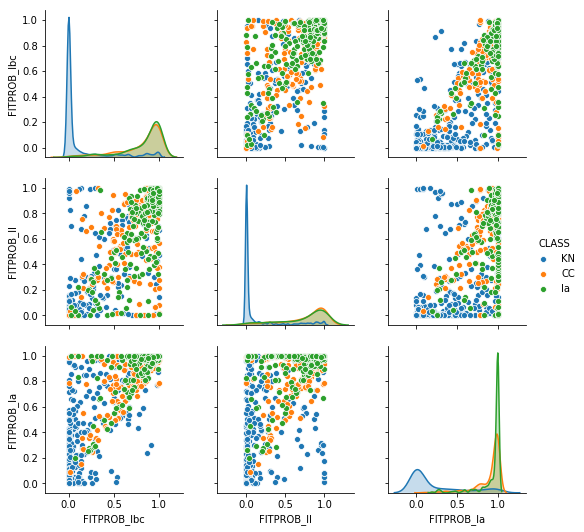

```python
df = dataset[['FITPROB_Ibc', 'FITPROB_II', 'FITPROB_Ia', 'CLASS']].copy()
sns.pairplot(df, hue='CLASS');
```

# Our task:

### Based on these data, develop a set of rules for determining whether an object is a KN or a SN

Any ideas?

# This was what I tried...

Maybe there exists a set of weights (`w0`, `w1`, `w2`) such that

$$ w_0 \times \textrm{FITPROB_Ia} + w_1 \times \textrm{FITPROB_Ibc} + w_2 \times \textrm{FITPROB_II} $$

is characteristic of whether an object is a KN or an SN.

To make this more explicit, let's include a `w3` and say if

$$ w_0 \times \textrm{FITPROB_Ia} + w_1 \times \textrm{FITPROB_Ibc} + w_2 \times \textrm{FITPROB_II} > w_3 $$

then the object is a KN. Otherwise, we'll say our rules classified it as a SN.

To find the set (`w0`, `w1`, `w2`, `w3`) such that our rule leads to the most accurate prediction of a KN versus a SN, let's just try all the possibilities.

*Disclaimer*: this is not a good idea

Okay whatever, let's do it anyways.

```python
# Let's try all the combinations of weights we can think of

(w0_arr, w1_arr, w2_arr, w3_arr) = tuple([np.linspace(-1, 1, 21)]) * 4

weight_matrix = []
for w0 in w0_arr:
    for w1 in w1_arr:
        for w2 in w2_arr:
            for w3 in w3_arr:
                weight_matrix.append([w0, w1, w2, w3])

weight_matrix = np.array(weight_matrix)
```

```python
print("Number of weight combinations:", weight_matrix.shape[0])

print("\nA small section of the matrix:\n", weight_matrix[1190:1195])
```

```
Number of weight combinations: 194481

A small section of the matrix:
 [[-1.  -0.8  0.4  0.4]
 [-1.  -0.8  0.4  0.5]
 [-1.  -0.8  0.4  0.6]
 [-1.  -0.8  0.4  0.7]
 [-1.  -0.8  0.4  0.8]]
```

```python
# Now let's apply our weights to our dataset using matrix multiplication

df['BIAS'] = -1.0
feature_matrix = df[['FITPROB_Ibc', 'FITPROB_II', 'FITPROB_Ia', 'BIAS']].values.T

predictions = np.dot(weight_matrix, feature_matrix)
```

```python
print("Feature matrix shape:", feature_matrix.shape)
print("Weight matrix shape:", weight_matrix.shape)
print("Predictions shape:", predictions.shape)
```

```
Feature matrix shape: (4, 1103)
Weight matrix shape: (194481, 4)
Predictions shape: (194481, 1103)
```

```python
# Now let's see how we did

# Evaluate classifications
binary_predictions = np.where(predictions > 0.0, 1, 0)
binary_truth = np.where(df['CLASS'].values == 'KN', 1, 0)

# Calculate the accuracy of each weight set
accuracies = [np.sum(binary_truth == binary_predictions[i,:]) / len(binary_truth)
              for i in range(len(binary_predictions))]
```

```python
best_index = np.argmax(accuracies)
best_weights = weight_matrix[best_index]
best_accuracy = accuracies[best_index]
```

```python
print(best_accuracy)
```

```
0.898458748866727
```

```python
print(best_weights)
```

```
[-0.8 -0.7 -0.7 -1. ]
```

## Recap

So, we did it! But can we do it in a smarter way?

What are the weaknesses of our approach?

- We had to specify every single weight combination
- We were restricted to the weights we specified
- Golly this was slow when I ran it

## A slightly smarter approach to finding the best weights

1. Start with an initial set of weights
2. For each example in your dataset...
   - apply the current weights to it to get a prediction
   - calcultate the difference between the prediction and the truth
   - update the current weights by a factor corresponding to the difference
3. Cycle through your dataset as many times as you need to reach convergence

It can be shown mathematically that the difference in step 2b will decrease monotonically with each iteration through the entire dataset.

(It's just one partial derivative and some linear algebra, so it's not scary at all. Ask me offline if you want to get into the math.)

The algorithm we just described can be written in code like this:

```
def fit(X, y, n_iter, eta):

    weights = np.zeros(X.shape[1])

    # Cycle through your dataset as many times as you want
    for _ in range(n_iter):

        # Cycle through each example in your dataset
        for xi, target in zip(X, y):

            # Get prediction from current weights
            result_from_applying_weights = np.dot(xi, weights)
            prediction = 1 if result_from_applying_weights > 0 else 0

            # Get the difference between the truth and your prediction
            update = eta * (target - prediction)

            # Update the current_weights
            weights += update * xi

    return weights
```

Where `X` is your `feature_matrix` from before, `y` is the `CLASS` column, `n_iter` is the number of times you want to cycle through your dataset, and `eta` controls how much the weights get updated each time.

I have incorporated the `fit` function into an object named `Perceptron`, so let's see how it does.

```python
p = Perceptron(n_iter=5000, eta=0.1)
```

```python
p.fit(X, y)
print(p.w_)
```

```
[ 0.10077174 -0.13874438 -0.0170651  -0.10782212]
```

```python
p_pred = p.predict(X)
accuracy = np.sum(y == p_pred) / len(y)
print(accuracy)
```

```
0.8884859474161378
```

### Evaluating the Perceptron

So the performance was about as good as the "try all the weights" approach, but the real advantage becomes clear if take a look at the weights of the Perceptron as it fit the dataset.

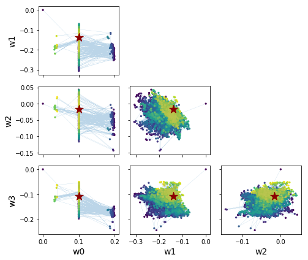

```python
plot_weight_space(weight_df)
```

## Example Summary

The Perceptron had a few advantages over our "greedy" approach:

- It didn't need to try all the weights
- It only spent time trying weights that had a good chance to be the best ones
- It was able to try weight combinations that we didn't specify ahead of time

Essentially, the Perceptron did the work of finding the best weights on it's own; we just told it two things:

1. How to decide whether a set of weights was good or bad
2. How to choose a new set of weights in a favorable way

**And that is machine learning.**

Based on available data, develop a set of rules to make decisions about new data.

# Situations where machine learning can be applied

[figure not shown]

For the remainder of this tutorial, I'll focus on supervised classification.

# Machine learning best practices

With automated rule-finding approaches, there are some weaknesses we have to be aware of:

1. The rules found by your ML algorithm will always be a function of the training data
2. The ML algorithm may fit to the noise in your data if you're not careful

So next we'll look at how to utilize a ML algorithm in a way that will generalize well to unseen data.

## Expecting the unexpected

Let's try out a different machine learning alrogithm. I'll cover the behind-the-scenes part about it soon, but for now, let's just use it out of the box.

The `DecisionTreeClassifier`:

[figure not shown]

Let's fit our `DecisionTreeClassifier` on the data just like we did with the `Perceptron`:

```python
from sklearn.tree import DecisionTreeClassifier
from sklearn.metrics import accuracy_score

dtc = DecisionTreeClassifier()

# Read in the dataset
dataset = pd.read_csv('training_set.csv')

# Select the FITPROB and CLASS columns
X = dataset[['FITPROB_Ia', 'FITPROB_Ibc', 'FITPROB_II']].values
y = dataset['CLASS'].values

# Train the classifier
dtc.fit(X, y)

# Predict on the dataset and check it's accuracy
y_pred = dtc.predict(X)

print("Accuracy: ", accuracy_score(y, y_pred))
```

```
Accuracy:  1.0
```

Well, you can't do much better than that!

But. Let's try this classifier on some new data...

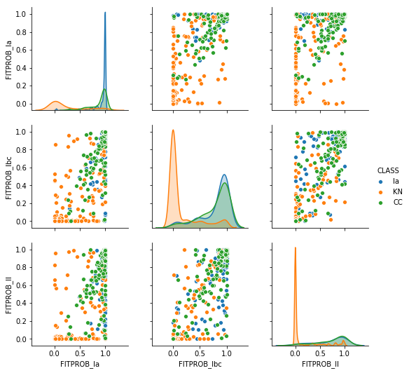

```python
test_dataset = pd.read_csv('testing_set.csv')
sns.pairplot(test_dataset[['FITPROB_Ia', 'FITPROB_Ibc', 'FITPROB_II', 'CLASS']], hue='CLASS');
```

```python
# Using our already trained DecisionTreeClassifier on the new data

# Format the data for the classifier
X_test = test_dataset[['FITPROB_Ia', 'FITPROB_Ibc', 'FITPROB_II']].values
y_test = test_dataset['CLASS'].values

# Predict the class of the new data
y_test_pred = dtc.predict(X_test)

# Output the accuracy
print("Accuracy: ", accuracy_score(y_test, y_test_pred))
```

```
Accuracy:  0.6363636363636364
```

So that sucked.

Why did it suck? Well when the classifier learned the "best classification rules" from the training set, it effectively memorized the training set rather than locking on to the underlying information that will differentiate a KN from a SN.

### Training and Validation Sets

The ML way to prepare for unseen data is to reserve a portion of your training set for testing. We'll call this portion the "validation set."

Scikit-Learn has a convenient function to do this split for us:

```python
from sklearn.model_selection import train_test_split

X_train, X_validate, y_train, y_validate = train_test_split(X, y, test_size=0.33, stratify=y, random_state=42)
```

Now let's let the classifier only learn the rules from the training set and see how it performs on the validation set.

```python
dtc.fit(X_train, y_train)

y_validate_pred = dtc.predict(X_validate)

print("Accuracy: ", accuracy_score(y_validate, y_validate_pred))
```

```
Accuracy:  0.6593406593406593
```

You may be disuaded by the low accuracy, but I would argue this has been a success.

We can now use the validation set as a reliable identifier for how well we should expect to perform on new data.

Our next step will be to do something about the low accuracy.

### Hyperparameter tuning

All algorithms will have parameters that we can tweak by hand to improve the perofrmance. For example, in the `Perceptron` these were the learning rate `eta` and the number of iterations `n_iter`.

Let's see what our options are for the `DecisionTreeClassifier`:

```python
print(dtc)
```

```
DecisionTreeClassifier(class_weight=None, criterion='gini', max_depth=None,
            max_features=None, max_leaf_nodes=None,
            min_impurity_decrease=0.0, min_impurity_split=None,
            min_samples_leaf=1, min_samples_split=2,
            min_weight_fraction_leaf=0.0, presort=False, random_state=None,
            splitter='best')
```

Seems like we have a lot of options. You can look at [the excellent SciKit-Learn docs](https://scikit-learn.org/stable/modules/generated/sklearn.tree.DecisionTreeClassifier.html) for the specifics of what these things do.

As an example, let's change the `max_depth` parameter. We'll choose whichever `max_depth` will lead to the highest accuracy on the **validation** set.

```python
training_accuracies, validation_accuracies = [], []

for max_depth in [1, 2, 3, 4, 5, 6, 7, 8, 9, 10, None]:
    # Instantiate a classifier
    dtc = DecisionTreeClassifier(max_depth=max_depth)

    # Fit on the training set
    dtc.fit(X_train, y_train)

    # Check the performance on the training and validation sets
    y_train_pred = dtc.predict(X_train)
    y_validate_pred = dtc.predict(X_validate)

    #Save the accuracies
    training_accuracies.append(accuracy_score(y_train, y_train_pred))
    validation_accuracies.append(accuracy_score(y_validate, y_validate_pred))
```

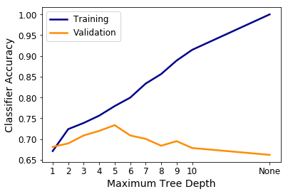

```python
plot_results(training_accuracies, validation_accuracies)
```

This should be the expected behavior. As you increase the depth of the tree, the tree becomes more likely to memorize the training data. And when the training data is memorized, you will likely perform poorly on new data.

This suggests we can imporve our accuracy by setting `max_depth=5`.

What about the other parameters?

### Hyperparameter tuning with GridSearch and Cross Validation

`GridSearch` is a built-in SciKit-Learn module for trying all the hyperparameter combinations you want.

Typically it is run also using a process called "Cross Validation." We have technically already been doing 1-fold cross validation by splitting the training set into a training fold and a validation fold.

**k-fold Cross Validation**, shown here as 10-fold cross validation:

[figure not shown]

Let's do this the SciKit-Learn way:

```python
from sklearn.model_selection import GridSearchCV

param_grid = {'max_depth': [1, 2, 3, 4, 5, 6, 7, 8, 9, 10, None],
              'criterion': ['gini', 'entropy'],
              'min_samples_leaf': [1, 3, 5, 10],
              'min_samples_split': [2, 3, 4, 5]}

gs = GridSearchCV(DecisionTreeClassifier(), param_grid, cv=5, n_jobs=-1)

gs.fit(X,y);
```

Let's peep the results!

```python
cv_df = pd.DataFrame(gs.cv_results_)
cv_df.head()
```

|  | mean_fit_time | std_fit_time | mean_score_time | std_score_time | param_criterion | param_max_depth | param_min_samples_leaf | param_min_samples_split | params | split0_test_score | ... | mean_test_score | std_test_score | rank_test_score | split0_train_score | split1_train_score | split2_train_score | split3_train_score | split4_train_score | mean_train_score | std_train_score |
| --- | --- | --- | --- | --- | --- | --- | --- | --- | --- | --- | --- | --- | --- | --- | --- | --- | --- | --- | --- | --- | --- |
| 0 | 0.005898 | 0.002809 | 0.000999 | 0.000304 | gini | 1 | 1 | 2 | {'criterion': 'gini', 'max_depth': 1, 'min_sam... | 0.675676 | ... | 0.673617 | 0.023273 | 328 | 0.674234 | 0.669694 | 0.684032 | 0.679502 | 0.667421 | 0.674976 | 0.006132 |
| 1 | 0.001996 | 0.000159 | 0.000639 | 0.000200 | gini | 1 | 1 | 3 | {'criterion': 'gini', 'max_depth': 1, 'min_sam... | 0.675676 | ... | 0.673617 | 0.023273 | 328 | 0.674234 | 0.669694 | 0.684032 | 0.679502 | 0.667421 | 0.674976 | 0.006132 |
| 2 | 0.002220 | 0.000616 | 0.000606 | 0.000190 | gini | 1 | 1 | 4 | {'criterion': 'gini', 'max_depth': 1, 'min_sam... | 0.675676 | ... | 0.673617 | 0.023273 | 328 | 0.674234 | 0.669694 | 0.684032 | 0.679502 | 0.667421 | 0.674976 | 0.006132 |
| 3 | 0.003502 | 0.002862 | 0.000426 | 0.000137 | gini | 1 | 1 | 5 | {'criterion': 'gini', 'max_depth': 1, 'min_sam... | 0.675676 | ... | 0.673617 | 0.023273 | 328 | 0.674234 | 0.669694 | 0.684032 | 0.679502 | 0.667421 | 0.674976 | 0.006132 |
| 4 | 0.002046 | 0.000254 | 0.000437 | 0.000094 | gini | 1 | 3 | 2 | {'criterion': 'gini', 'max_depth': 1, 'min_sam... | 0.675676 | ... | 0.673617 | 0.023273 | 328 | 0.674234 | 0.669694 | 0.684032 | 0.679502 | 0.667421 | 0.674976 | 0.006132 |

5 rows × 24 columns

This is how you can inspect all the details of your gridsearch. But, since we only care about the best set of hyperparameters, we can take the easy way:

```python
print(gs.best_params_)
```

```
{'criterion': 'gini', 'max_depth': 5, 'min_samples_leaf': 3, 'min_samples_split': 3}
```

GridSearchCV also loads up a version of your classifier with the best parameters:

```python
print(gs.best_estimator_)
```

```
DecisionTreeClassifier(class_weight=None, criterion='gini', max_depth=5,
            max_features=None, max_leaf_nodes=None,
            min_impurity_decrease=0.0, min_impurity_split=None,
            min_samples_leaf=3, min_samples_split=3,
            min_weight_fraction_leaf=0.0, presort=False, random_state=None,
            splitter='best')
```

Now let's see how we do on the test data...

```python
gs.best_estimator_.fit(X, y)
y_test_pred = gs.best_estimator_.predict(X_test)
print("Accuracy: ", accuracy_score(y_test_pred, y_test))
```

```
Accuracy:  0.7103594080338267
```

## ML Best Practices Summary

You absolutely need to take the steps to make sure your classifier will generalize to new data. You also need to make sure you're doing the best you can possibly do.

You can achieve both by:

- Reserving parts of your training set for validation
- Using the validation set to test out different versions of your classifier

Thankfully Sci-Kit learn makes this easy!

# Popular ML algorithms available to you

So far we've seen a `Perceptron` and a `DecisionTreeClassifier`. These are possibly the two most vanilla classifiers that exist.

Since we've been using Scikit-Learn, let's look at some of the popular classifiers that are available.

## Random Forests

The `RandomForestClassifier` is an ensemble of `DecisionTreeClassifier`s. It's also my personal favorite.

Each decision tree in the ensemble trains on a different subset of the training data, which incorporates cross-validation into your training. This process is called "bagging."

Each sample is also weighted according to how much it contributes to successful classifications or how much it confuses the classifer. This process is called "boosting."

In general, `RandomForestClassifier`s have the following benefits:

- Robust against the relative scaling of your data features
- Resistant to overfitting if you specify a max_depth
- Built-in multiprocessing
- Outputs probabilities instead of just predictions

Let's try it out!

```python
from sklearn.ensemble import RandomForestClassifier

rfc = RandomForestClassifier(n_estimators=50, max_depth=5, n_jobs=-1)

rfc.fit(X, y)

y_test_pred = rfc.predict(X_test)

print("Accuracy: ", accuracy_score(y_test, y_test_pred))
```

```
Accuracy:  0.7040169133192389
```

## k-Nearest Neighbors

For a given integer value of `k`, the classifier will look at each point in your feature space and look at the classes of the nearest `k` objects in your training set to this point. The classification will be based on a majority vote from those `k` objects.

[figure not shown]

Important notes with kNN:

- You absolutely, postively, 100% must scale your data
- You will have to develop a way to choose the best value for `k`

For this dataset, all the feature values are already between 0 and 1, so we're set. Now let's choose the best `k`.

```python
from sklearn.neighbors import KNeighborsClassifier

accuracies = []
for k in range(1, 11):
    knn = KNeighborsClassifier(n_neighbors=k)

    knn.fit(X_train, y_train)
    accuracies.append(accuracy_score(y_validate, knn.predict(X_validate)))
```

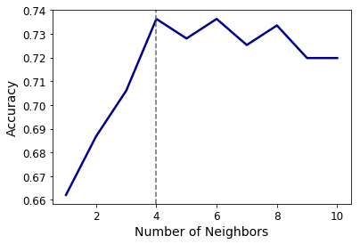

```python
plot_knn_results(accuracies)
```

## Support Vector Machines

A classic. SVMs work by partitioning your feature space. They work similarly to linear-least-squares regression, but just in reverse. They find the equations of the lines / planes/ hyperplanes that are the furthest from both classes of your data

[figure not shown]

```python
from sklearn.svm import SVC

svc = SVC(kernel='linear')

svc.fit(X_train, y_train)
y_validate_pred = svc.predict(X_validate)

print("Accuracy: ", accuracy_score(y_validate, y_validate_pred))
```

```
Accuracy:  0.7005494505494505
```

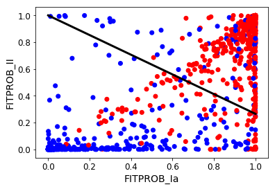

```python
plot_svm(svc)
```

## Algorithms Summary

- There are several ML algorithms out there, each with a different way of learning classification rules from your datasets.
- Most of them are well-documented and easy to use with Scikit-Learn
- The choice of algorithm will depended on the problem you're trying to solve and the properties of your data

# Overall Summary

Today I've described the underlying concepts of ML:

- Algorithmic approaches for making inferences on new data based on existing data

And touched on some ML best practices:

- Cross validation, validation sets, hyperparameter tuning

And also described some basic classifiers that you can play with in Scikit-Learn:

- Perceptrons, Decision Trees, Random Forests, Nearest Neighbors, and Support Vector Machines

Hopefully, you also noticed how straightforward it is to implement these algorithms using Scikit-Learn. And as a final summary, let's outline a typical ML workflow.

### A Typical ML Workflow

Let's choose the `RandomForestClassifier` as our algorithm and put everything from this talk together.

```python
# Load your training and testing data
train_dataset, test_dataset = pd.read_csv('training_set.csv'), pd.read_csv('testing_set.csv')

# Select the features you want to work with
X_train, y_train = train_dataset[['FITPROB_Ia', 'FITPROB_Ibc', 'FITPROB_II']].values, train_dataset['CLASS'].values
X_test, y_test = test_dataset[['FITPROB_Ia', 'FITPROB_Ibc', 'FITPROB_II']].values, test_dataset['CLASS'].values

# Instantiate a classifer and define the hyperparamters you want the check
rfc = RandomForestClassifier()
param_grid = {'n_estimators': [5, 10, 50, 100],
              'max_depth': [2, 3, 5, 7, 10, None],
              'criterion': ['gini', 'entropy'],
              'min_samples_split': [2, 3, 5, 8, 10],
              'min_samples_leaf': [1, 2, 4, 8],
              'max_leaf_nodes': [5, 10, 20, None]}

# Perform a Cross-Validated GridSearch
gs = GridSearchCV(rfc, param_grid, cv=5, n_jobs=-1)
gs.fit(X_train, y_train)

# Select the best estimator and check how you did on the testing data
print("Accuracy: ", accuracy_score(y_test, gs.best_estimator_.predict(X_test)))
```

```
Accuracy:  0.6892177589852009
```

For those of you keeping score at home, all that happened in 8 lines of code.

# Where to go next

If you're interested in playing with more SciKit-Learn stuff, check out some of the provided datasets available to you!

sklearn.datasets has several fun datasets to dig into. Some of the classics are:

- The Iris Dataset
- The Breast Cancer Dataset
- The Wine Dataset

Load a dataset, split it up, decide on your favorite features, train a classifier, and test on unseen data

Here's how this might look for the Iris dataset:

```python
from sklearn.datasets import load_iris

data = load_iris()
df = pd.DataFrame(data.data, columns=data.feature_names)
df['CLASS'] = data.target

df.head()
```

|  | sepal length (cm) | sepal width (cm) | petal length (cm) | petal width (cm) | CLASS |
| --- | --- | --- | --- | --- | --- |
| 0 | 5.1 | 3.5 | 1.4 | 0.2 | 0 |
| 1 | 4.9 | 3.0 | 1.4 | 0.2 | 0 |
| 2 | 4.7 | 3.2 | 1.3 | 0.2 | 0 |
| 3 | 4.6 | 3.1 | 1.5 | 0.2 | 0 |
| 4 | 5.0 | 3.6 | 1.4 | 0.2 | 0 |

Happy Machine Learning!

# Machine Learning

### Rob Morgan

rmorgan10.github.io